# **Assignment 10**

```python
# core
import matplotlib.pyplot as plt
import numpy as np
import pandas as pd

# ml
from sklearn import datasets as ds
from sklearn import linear_model as lm
from sklearn.neighbors import KNeighborsClassifier as KNN
from sklearn.model_selection import train_test_split as tts

#plotly or other graphing library
import plotly.express as px
import plotly.io as pio
pio.renderers.default="notebook"
```

```python
# Load datasets here once and assign to variables iris and boston
# Loading it from sklearn
iris = ds.load_iris()
```

**Q1**

**Data set: Iris**

- Return the first 5 rows of the data including the feature names as column headings in a DataFrame and a

separate Python list containing target names

```python
# pandas dataframe with column headings set to the feature names of the iris dataset
iris_df = pd.DataFrame(data=iris.data, columns=iris.feature_names)
# A seperate Python list containing target names
target_names = iris.target_names

# Returning the first 5 rows and the target names
print(iris_df.head(5))
print(target_names)
```

```
   sepal length (cm)  sepal width (cm)  petal length (cm)  petal width (cm)
0                5.1               3.5                1.4               0.2
1                4.9               3.0                1.4               0.2
2                4.7               3.2                1.3               0.2
3                4.6               3.1                1.5               0.2
4                5.0               3.6                1.4               0.2
['setosa' 'versicolor' 'virginica']
```

**Q2**

**Data set: Iris**

- Fit the Iris dataset into a kNN model with neighbors=5 and predict the category of observations passed in

argument new_observations. Return back the target names of each prediction (and not their encoded values, i.e. return setosa instead of 0).

```python
X = iris.data
y = iris.target

# They use the number 42 for random_state on DataCamp
X_train, X_test, y_train, y_test = tts(X, y, test_size=0.2, random_state=42, stratify=y)
knn = KNN(n_neighbors=5)

knn.fit(X_train, y_train)

# As shown maximum number for the 4 columns is 7.9 and the minimum is 0.1
print(iris_df.describe())

# Set seed for consistency
np.random.seed(42)

# # Randomly generated observations, lower bound is 0 and upperbound is 8
new_observations = np.random.uniform(0, 8, size=(3, 4))

# Predict the category of observations passed in argument new_observations
predictions= knn.predict(new_observations)

# Map encoded values to target names
predicted_categories = [target_names[pred] for pred in predictions]

# Print the predicted target names
for target in predicted_categories:
    print(target)
```

```
       sepal length (cm)  sepal width (cm)  petal length (cm)  \
count         150.000000        150.000000         150.000000
mean            5.843333          3.057333           3.758000
std             0.828066          0.435866           1.765298
min             4.300000          2.000000           1.000000
25%             5.100000          2.800000           1.600000
50%             5.800000          3.000000           4.350000
75%             6.400000          3.300000           5.100000
max             7.900000          4.400000           6.900000

       petal width (cm)
count        150.000000
mean           1.199333
std            0.762238
min            0.100000
25%            0.300000
50%            1.300000
75%            1.800000
max            2.500000
virginica
setosa
setosa
```

**Q3** 15 pts

**Data set: Iris**

- Split the Iris dataset into a train / test model with the split ratio between the two established by the function parameter split.
- Fit KNN with the training data with number of neighbors equal to the function parameter neighbors
- Generate and return back an accuracy score using the test data that was split out

```python
"""
I am going to reuse X_train, X_test, y_train, y_test from Q2
There are 150 observed instances so I'm just going to randomly pick 15 for the number of neighbors
"""
knn = KNN(n_neighbors = 15)
knn.fit(X_train, y_train)
# Accuracy score
print(knn.score(X_test, y_test))
```

```
0.9666666666666667
```

**Q4**

**Data set: Iris**

- Generate an overfitting / underfitting curve of kNN each of the testing and training accuracy performance scores series for a range of neighbor (k) values from 1 to 30 and plot the curves (number of neighbors is x-axis, performance score is y-axis on the chart).

```
[ 1  2  3  4  5  6  7  8  9 10 11 12 13 14 15 16 17 18 19 20 21 22 23 24
 25 26 27 28 29 30]
 [1.0, 0.975, 0.9583333333333334, 0.9583333333333334, 0.9666666666666667, 0.9666666666666667, 0.975, 0.975, 0.975, 0.975, 0.975, 0.9666666666666667, 0.975, 0.9833333333333333, 0.975, 0.9833333333333333, 0.9833333333333333, 0.9833333333333333, 0.975, 0.9833333333333333, 0.975, 0.9833333333333333, 0.9…
 [0.9666666666666667, 0.9333333333333333, 1.0, 1.0, 1.0, 0.9666666666666667, 0.9666666666666667, 0.9666666666666667, 1.0, 1.0, 0.9666666666666667, 0.9666666666666667, 0.9666666666666667, 0.9666666666666667, 0.9666666666666667, 0.9666666666666667, 0.9666666666666667, 0.9666666666666667, 0.96666666666…
```

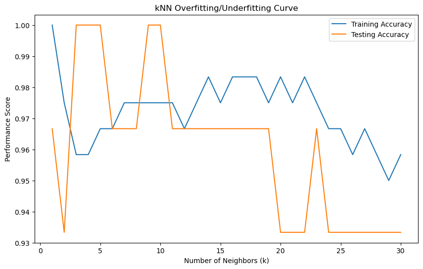

[interactive chart not shown]

```python
# Values of 1 to 30 in numpy array
neighbors = np.arange(1, 31)

# Lists to store the accuracies for testing and training
train_accuracies = []
test_accuracies = []

for neighbor in neighbors:
	knn = KNN(n_neighbors=neighbor)
	knn.fit(X_train, y_train)
	train_accuracies.append(knn.score(X_train, y_train))
	test_accuracies.append(knn.score(X_test, y_test))

print(neighbors, '\n', train_accuracies, '\n', test_accuracies)

# Matplotlib version
plt.figure(figsize=(10, 6))
plt.plot(neighbors, train_accuracies, label='Training Accuracy')
plt.plot(neighbors, test_accuracies, label='Testing Accuracy')
plt.title('kNN Overfitting/Underfitting Curve')
plt.xlabel('Number of Neighbors (k)')
plt.ylabel('Performance Score')
plt.legend()
plt.show()

# Create a DataFrame for usage to plot with Plotly
df = pd.DataFrame({'k_values': neighbors, 'Training Accuracy': train_accuracies, 'Testing Accuracy': test_accuracies})

# Plotly version
fig = px.line(df, x='k_values', y=['Training Accuracy', 'Testing Accuracy'],
              labels={'value': 'Performance Score', 'k_values': 'Number of Neighbors (k)'},
              title='kNN Overfitting/Underfitting Curve Plot')

# Show the interactive plot
fig.show()
```